# HousePricePrediction

Chapter 1 - Define the Problem  
Chapter 2 - Gather the Data  
Chapter 3 - Exploratory Data Analysis  
Chapter 4 - Data Cleaning  
Chapter 5 - Model Data  
Chapter 6 - Submission

## **Chapter 1 - Define the Problem**

캐글코리아에서 주최한 competition 입니다.  
Washington의 Kingcounty의 부동산 정보를 활용하였습니다.  
20가지의 변수가 제공되며 15035개의 부동산 정보로부터(traindata), 6468개의 개의 집값을(testdata) 예측해내는게 목적입니다.

해당 competition의 description은 <a href = 'https://www.kaggle.com/c/2019-2nd-ml-month-with-kakr'> 여기를 클릭 </a> 해서 확인하실 수 있습니다.

### **Chapter 2 - Gather the Data**

competition 데이터 description은 <a href = 'https://www.kaggle.com/c/2019-2nd-ml-month-with-kakr/data'>여기</a> 를 눌러 확인하실 수 있습니다.  
데이터의 출처는 <a href = 'https://www.kaggle.com/harlfoxem/housesalesprediction'>https://www.kaggle.com/harlfoxem/housesalesprediction</a> 이곳에서 확인하실 수 있습니다.

**Data fields**

1. ID : 집을 구분하는 번호
2. date : 집을 구매한 날짜
3. price : 집의 가격(Target variable)
4. bedrooms : 침실의 수
5. bathrooms : 침실 개수 당 화장실의 수(화장실의 수 / 침실의 수 )
6. sqft_living : 주거 공간의 평방 피트(면적)
7. sqft_lot : 부지의 평방 피트(면적)
8. floors : 집의 층 수
9. waterfront : 집의 전방에 강이 흐르는지 유무 (a.k.a. 리버뷰)
10. view : 집이 얼마나 좋아 보이는지의 정도
11. condition : 집의 전반적인 상태
12. grade : King County grading 시스템 기준으로 매긴 집의 등급
13. sqft_above : 지하실을 제외한 평방 피트(면적)
14. sqft_basement : 지하실의 평방 피트(면적)
15. yr_built : 지어진 년도
16. yr_renovated : 집을 재건축한 년도
17. zipcode : 우편번호
18. lat : 위도
19. long : 경도
20. sqft_living15 : 2015년 기준 주거 공간의 평방 피트(면적, 집을 재건축했다면, 변화가 있을 수 있음)
21. sqft_lot15 : 2015년 기준 부지의 평방 피트(면적, 집을 재건축했다면, 변화가 있을 수 있음)

### **Chapter 2 - 1 - import Libraries**

```python
import pandas as pd
pd.set_option('display.max_columns', 500)

from pandas import Series
import numpy as np
import scipy as sp
import sklearn
import copy

#misc libraries
import random as rnd
import time

#ignore warnings
import warnings
warnings.filterwarnings('ignore')

#Common Model Algorithms
from sklearn import svm, tree, linear_model, neighbors, naive_bayes, ensemble, discriminant_analysis, gaussian_process

import xgboost as xgb
from xgboost import XGBRegressor

#Common Model Helpers
from sklearn import preprocessing
from sklearn.preprocessing import OneHotEncoder, LabelEncoder
from sklearn import feature_selection
from sklearn import model_selection
from sklearn.model_selection import train_test_split
from sklearn import metrics
from sklearn.metrics import mean_squared_error
from sklearn.model_selection import KFold


#Visualization
import matplotlib as mpl
import matplotlib.pyplot as plt
import matplotlib.pylab as pylab
import seaborn as sns
from pandas.tools.plotting import scatter_matrix
import missingno as msno

#Configure Visualization Defaults
%matplotlib inline
mpl.style.use('seaborn')
```

### **Chapter 2 - 2 - Check data set**

분석을 시작하기에 앞서 데이터를 이해하는 것이 가장 중요합니다.  
pandas 라이브러리를 사용하여 주어진 데이터를 읽어온 후, 데이터를 살펴보도록 하겠습니다.

```python
df_train = pd.read_csv('C:/Users/hongo/OneDrive/BIGDATA/kaggle/HousePricePrediction/train.csv')
df_test = pd.read_csv('C:/Users/hongo/OneDrive/BIGDATA/kaggle/HousePricePrediction/test.csv')

df_all = pd.concat([df_train, df_test])
```

```python
print('train data : ',df_train.shape)
print('test data : ',df_test.shape)
```

```
train data :  (15035, 21)
test data :  (6468, 20)
```

```python
df_train.head()
```

|  | id | date | price | bedrooms | bathrooms | sqft_living | sqft_lot | floors | waterfront | view | condition | grade | sqft_above | sqft_basement | yr_built | yr_renovated | zipcode | lat | long | sqft_living15 | sqft_lot15 |
| --- | --- | --- | --- | --- | --- | --- | --- | --- | --- | --- | --- | --- | --- | --- | --- | --- | --- | --- | --- | --- | --- |
| 0 | 0 | 20141013T000000 | 221900.0 | 3 | 1.00 | 1180 | 5650 | 1.0 | 0 | 0 | 3 | 7 | 1180 | 0 | 1955 | 0 | 98178 | 47.5112 | -122.257 | 1340 | 5650 |
| 1 | 1 | 20150225T000000 | 180000.0 | 2 | 1.00 | 770 | 10000 | 1.0 | 0 | 0 | 3 | 6 | 770 | 0 | 1933 | 0 | 98028 | 47.7379 | -122.233 | 2720 | 8062 |
| 2 | 2 | 20150218T000000 | 510000.0 | 3 | 2.00 | 1680 | 8080 | 1.0 | 0 | 0 | 3 | 8 | 1680 | 0 | 1987 | 0 | 98074 | 47.6168 | -122.045 | 1800 | 7503 |
| 3 | 3 | 20140627T000000 | 257500.0 | 3 | 2.25 | 1715 | 6819 | 2.0 | 0 | 0 | 3 | 7 | 1715 | 0 | 1995 | 0 | 98003 | 47.3097 | -122.327 | 2238 | 6819 |
| 4 | 4 | 20150115T000000 | 291850.0 | 3 | 1.50 | 1060 | 9711 | 1.0 | 0 | 0 | 3 | 7 | 1060 | 0 | 1963 | 0 | 98198 | 47.4095 | -122.315 | 1650 | 9711 |

```python
df_train.describe(include='all')
```

|  | id | date | price | bedrooms | bathrooms | sqft_living | sqft_lot | floors | waterfront | view | condition | grade | sqft_above | sqft_basement | yr_built | yr_renovated | zipcode | lat | long | sqft_living15 | sqft_lot15 |
| --- | --- | --- | --- | --- | --- | --- | --- | --- | --- | --- | --- | --- | --- | --- | --- | --- | --- | --- | --- | --- | --- |
| count | 15035.000000 | 15035 | 1.503500e+04 | 15035.000000 | 15035.000000 | 15035.000000 | 1.503500e+04 | 15035.000000 | 15035.000000 | 15035.000000 | 15035.000000 | 15035.000000 | 15035.000000 | 15035.000000 | 15035.000000 | 15035.000000 | 15035.000000 | 15035.000000 | 15035.000000 | 15035.000000 | 15035.000000 |
| unique | NaN | 365 | NaN | NaN | NaN | NaN | NaN | NaN | NaN | NaN | NaN | NaN | NaN | NaN | NaN | NaN | NaN | NaN | NaN | NaN | NaN |
| top | NaN | 20140623T000000 | NaN | NaN | NaN | NaN | NaN | NaN | NaN | NaN | NaN | NaN | NaN | NaN | NaN | NaN | NaN | NaN | NaN | NaN | NaN |
| freq | NaN | 101 | NaN | NaN | NaN | NaN | NaN | NaN | NaN | NaN | NaN | NaN | NaN | NaN | NaN | NaN | NaN | NaN | NaN | NaN | NaN |
| mean | 7517.000000 | NaN | 5.406827e+05 | 3.369139 | 2.115065 | 2083.790223 | 1.529697e+04 | 1.498071 | 0.007117 | 0.234253 | 3.406651 | 7.660725 | 1794.158164 | 289.632059 | 1971.100432 | 83.798936 | 98078.031726 | 47.560721 | -122.213677 | 1992.754772 | 12823.884935 |
| std | 4340.374984 | NaN | 3.715247e+05 | 0.902721 | 0.767519 | 922.134087 | 4.261282e+04 | 0.538522 | 0.084063 | 0.763376 | 0.646505 | 1.179803 | 831.738609 | 440.663284 | 29.407612 | 400.398498 | 53.297815 | 0.138164 | 0.141294 | 691.456442 | 27736.259787 |
| min | 0.000000 | NaN | 7.800000e+04 | 0.000000 | 0.000000 | 290.000000 | 5.200000e+02 | 1.000000 | 0.000000 | 0.000000 | 1.000000 | 1.000000 | 290.000000 | 0.000000 | 1900.000000 | 0.000000 | 98001.000000 | 47.155900 | -122.519000 | 399.000000 | 651.000000 |
| 25% | 3758.500000 | NaN | 3.220000e+05 | 3.000000 | 1.750000 | 1430.000000 | 5.027500e+03 | 1.000000 | 0.000000 | 0.000000 | 3.000000 | 7.000000 | 1190.000000 | 0.000000 | 1951.000000 | 0.000000 | 98033.000000 | 47.472700 | -122.328000 | 1490.000000 | 5100.000000 |
| 50% | 7517.000000 | NaN | 4.500000e+05 | 3.000000 | 2.250000 | 1910.000000 | 7.620000e+03 | 1.500000 | 0.000000 | 0.000000 | 3.000000 | 7.000000 | 1570.000000 | 0.000000 | 1975.000000 | 0.000000 | 98065.000000 | 47.571900 | -122.231000 | 1850.000000 | 7610.000000 |
| 75% | 11275.500000 | NaN | 6.450000e+05 | 4.000000 | 2.500000 | 2560.000000 | 1.069550e+04 | 2.000000 | 0.000000 | 0.000000 | 4.000000 | 8.000000 | 2230.000000 | 550.000000 | 1997.000000 | 0.000000 | 98117.000000 | 47.678300 | -122.126000 | 2360.000000 | 10076.000000 |
| max | 15034.000000 | NaN | 7.700000e+06 | 10.000000 | 8.000000 | 13540.000000 | 1.651359e+06 | 3.500000 | 1.000000 | 4.000000 | 5.000000 | 13.000000 | 9410.000000 | 4130.000000 | 2015.000000 | 2015.000000 | 98199.000000 | 47.777600 | -121.315000 | 6210.000000 | 871200.000000 |

```python
print('-'*50)
print('                    df_train                    ')
print('-'*50)
df_train.info()
print('\n'*3)
print('-'*50)
print('                    df_test                    ')
print('-'*50)
df_test.info()
```

```
--------------------------------------------------
                    df_train
--------------------------------------------------
<class 'pandas.core.frame.DataFrame'>
RangeIndex: 15035 entries, 0 to 15034
Data columns (total 21 columns):
id               15035 non-null int64
date             15035 non-null object
price            15035 non-null float64
bedrooms         15035 non-null int64
bathrooms        15035 non-null float64
sqft_living      15035 non-null int64
sqft_lot         15035 non-null int64
floors           15035 non-null float64
waterfront       15035 non-null int64
view             15035 non-null int64
condition        15035 non-null int64
grade            15035 non-null int64
sqft_above       15035 non-null int64
sqft_basement    15035 non-null int64
yr_built         15035 non-null int64
yr_renovated     15035 non-null int64
zipcode          15035 non-null int64
lat              15035 non-null float64
long             15035 non-null float64
sqft_living15    15035 non-null int64
sqft_lot15       15035 non-null int64
dtypes: float64(5), int64(15), object(1)
memory usage: 2.4+ MB




--------------------------------------------------
                    df_test
--------------------------------------------------
<class 'pandas.core.frame.DataFrame'>
RangeIndex: 6468 entries, 0 to 6467
Data columns (total 20 columns):
id               6468 non-null int64
date             6468 non-null object
bedrooms         6468 non-null int64
bathrooms        6468 non-null float64
sqft_living      6468 non-null int64
sqft_lot         6468 non-null int64
floors           6468 non-null float64
waterfront       6468 non-null int64
view             6468 non-null int64
condition        6468 non-null int64
grade            6468 non-null int64
sqft_above       6468 non-null int64
sqft_basement    6468 non-null int64
yr_built         6468 non-null int64
yr_renovated     6468 non-null int64
zipcode          6468 non-null int64
lat              6468 non-null float64
long             6468 non-null float64
sqft_living15    6468 non-null int64
sqft_lot15       6468 non-null int64
dtypes: float64(4), int64(15), object(1)
memory usage: 1010.7+ KB
```

### **Chapter 2 - 3 - Check Null Data**

결측값은 예측모델에 굉장히 부정적인 영향을 주므로, 반드시 조치를 취해아합니다.  
따라서 데이터를 체크할 때, 결측값을 반드시 확인해보도록 합니다.

이번 데이터에서는 결측값은 보이지 않습니다.

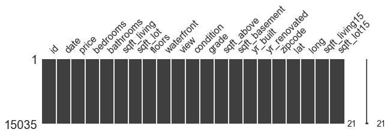

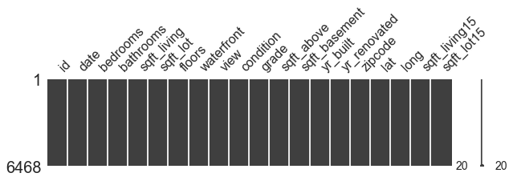

```python
msno.matrix(df = df_train, figsize=(10,2))

msno.matrix(df = df_test, figsize=(10,2))
```

```python
for col in df_test.columns:
    print('col : {:<10} \t count : {:<5} \t Null count : {:<5}  Percent of Null value : {:.2f}%'.format(col,df_test[col].shape[0], df_test[col].isnull().sum(), df_test[col].isnull().sum()/df_test[col].shape[0]*100))
```

```
col : id         	 count : 6468  	 Null count : 0      Percent of Null value : 0.00%
col : date       	 count : 6468  	 Null count : 0      Percent of Null value : 0.00%
col : bedrooms   	 count : 6468  	 Null count : 0      Percent of Null value : 0.00%
col : bathrooms  	 count : 6468  	 Null count : 0      Percent of Null value : 0.00%
col : sqft_living 	 count : 6468  	 Null count : 0      Percent of Null value : 0.00%
col : sqft_lot   	 count : 6468  	 Null count : 0      Percent of Null value : 0.00%
col : floors     	 count : 6468  	 Null count : 0      Percent of Null value : 0.00%
col : waterfront 	 count : 6468  	 Null count : 0      Percent of Null value : 0.00%
col : view       	 count : 6468  	 Null count : 0      Percent of Null value : 0.00%
col : condition  	 count : 6468  	 Null count : 0      Percent of Null value : 0.00%
col : grade      	 count : 6468  	 Null count : 0      Percent of Null value : 0.00%
col : sqft_above 	 count : 6468  	 Null count : 0      Percent of Null value : 0.00%
col : sqft_basement 	 count : 6468  	 Null count : 0      Percent of Null value : 0.00%
col : yr_built   	 count : 6468  	 Null count : 0      Percent of Null value : 0.00%
col : yr_renovated 	 count : 6468  	 Null count : 0      Percent of Null value : 0.00%
col : zipcode    	 count : 6468  	 Null count : 0      Percent of Null value : 0.00%
col : lat        	 count : 6468  	 Null count : 0      Percent of Null value : 0.00%
col : long       	 count : 6468  	 Null count : 0      Percent of Null value : 0.00%
col : sqft_living15 	 count : 6468  	 Null count : 0      Percent of Null value : 0.00%
col : sqft_lot15 	 count : 6468  	 Null count : 0      Percent of Null value : 0.00%
```

```python
for col in df_train.columns:
    print('col : {:<10} \t count : {:<5} \t Null count : {:<5}  Percent of Null value : {:.2f}%'.format(col,df_train[col].shape[0], df_train[col].isnull().sum(), df_train[col].isnull().sum()/df_train[col].shape[0]*100))
```

```
col : id         	 count : 15035 	 Null count : 0      Percent of Null value : 0.00%
col : date       	 count : 15035 	 Null count : 0      Percent of Null value : 0.00%
col : price      	 count : 15035 	 Null count : 0      Percent of Null value : 0.00%
col : bedrooms   	 count : 15035 	 Null count : 0      Percent of Null value : 0.00%
col : bathrooms  	 count : 15035 	 Null count : 0      Percent of Null value : 0.00%
col : sqft_living 	 count : 15035 	 Null count : 0      Percent of Null value : 0.00%
col : sqft_lot   	 count : 15035 	 Null count : 0      Percent of Null value : 0.00%
col : floors     	 count : 15035 	 Null count : 0      Percent of Null value : 0.00%
col : waterfront 	 count : 15035 	 Null count : 0      Percent of Null value : 0.00%
col : view       	 count : 15035 	 Null count : 0      Percent of Null value : 0.00%
col : condition  	 count : 15035 	 Null count : 0      Percent of Null value : 0.00%
col : grade      	 count : 15035 	 Null count : 0      Percent of Null value : 0.00%
col : sqft_above 	 count : 15035 	 Null count : 0      Percent of Null value : 0.00%
col : sqft_basement 	 count : 15035 	 Null count : 0      Percent of Null value : 0.00%
col : yr_built   	 count : 15035 	 Null count : 0      Percent of Null value : 0.00%
col : yr_renovated 	 count : 15035 	 Null count : 0      Percent of Null value : 0.00%
col : zipcode    	 count : 15035 	 Null count : 0      Percent of Null value : 0.00%
col : lat        	 count : 15035 	 Null count : 0      Percent of Null value : 0.00%
col : long       	 count : 15035 	 Null count : 0      Percent of Null value : 0.00%
col : sqft_living15 	 count : 15035 	 Null count : 0      Percent of Null value : 0.00%
col : sqft_lot15 	 count : 15035 	 Null count : 0      Percent of Null value : 0.00%
```

## **Chapter 3 - Exploratory Data Analysis**

우리가 가지고있는 데이터의 형태와 특징들, 그리고 각각의 변인들과 타겟레이블과의 관계를 시각화하여 알아보겠습니다.

```python
#for cnt,i in enumerate(df_train.columns) :
#    print('### **'+str(cnt+1),'-',i.upper()+'**')
```

### **1 - Price**

우리의 타겟레이블입니다.

```python
df_train['price'].dtype
```

```
dtype('float64')
```

```python
df_train['price'].describe(include='all')
```

```
count    1.503500e+04
mean     5.406827e+05
std      3.715247e+05
min      7.800000e+04
25%      3.220000e+05
50%      4.500000e+05
75%      6.450000e+05
max      7.700000e+06
Name: price, dtype: float64
```

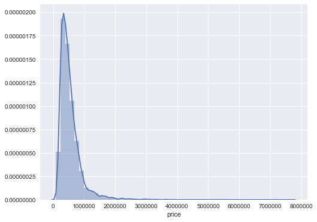

```python
f, ax = plt.subplots(1,1, figsize=(8,6))

sns.distplot(df_train['price'])
```

### **2 - ID**

제공받은 데이터의 rownumber외의 기능은 없어보이므로 ID값은 SKIP하겠습니다.

### **3 - DATE**

집을 구매한 날짜를 의미하는 데이터입니다.  
데이터는 시분초 까지 포함하는 형식이지만 년월일 까지만 데이터가 들어있고 T이하의 시간데이터는 데이터가 전혀 없습니다.  
2014년 5월 2일부터, 2015년 5월 14일까지 대략 1년의 기간을 가지고있습니다.

DATE는 년월 까지로만 확인해봤습니다.

금액의 추이를 살펴보면, 지속적으로 하락세를 보이다가 2015년도 2월부터 반등해서 올라가는 형태를 보입니다.  
거래성립횟수는 1월부터 반등하는 것으로 보이네요.  
다만 5월의 거래횟수는 거래데이터의 최종일자가 5월 14일까지로 덜 들어온채로 마무리 되어서 인지 거래량이 비 정상적으로 떨어집니다.

```python
print('minlength : ' + str(df_train['date'].apply(len).min()))
print('maxlength : ' + str(df_train['date'].apply(len).max()))
print('character after date format : ' + str(df_train['date'].str[8:].unique()))
print('min date : ' + df_train['date'].min())
print('max date : ' + df_train['date'].max())
```

```
minlength : 15
maxlength : 15
character after date format : ['T000000']
min date : 20140502T000000
max date : 20150514T000000
```

```python
df_train['YYYYMM'] = df_train.date.str[:6]
df_test['YYYYMM'] = df_test.date.str[:6]
```

```python
df_train[['date','YYYYMM']].head()
```

|  | date | YYYYMM |
| --- | --- | --- |
| 0 | 20141013T000000 | 201410 |
| 1 | 20150225T000000 | 201502 |
| 2 | 20150218T000000 | 201502 |
| 3 | 20140627T000000 | 201406 |
| 4 | 20150115T000000 | 201501 |

```python
df_train[['YYYYMM','price']].groupby('YYYYMM').mean()
```

| YYYYMM | price |
| --- | --- |
| 201405 | 549649.856230 |
| 201406 | 549902.546667 |
| 201407 | 546033.214918 |
| 201408 | 533536.653196 |
| 201409 | 532016.436838 |
| 201410 | 535156.146747 |
| 201411 | 523098.199796 |
| 201412 | 531244.522908 |
| 201501 | 526782.397974 |
| 201502 | 510550.813539 |
| 201503 | 546050.748462 |
| 201504 | 562234.612459 |
| 201505 | 576398.908482 |

```python
df_train[['YYYYMM','price']].groupby('YYYYMM', as_index=False).count()
```

|  | YYYYMM | price |
| --- | --- | --- |
| 0 | 201405 | 1252 |
| 1 | 201406 | 1500 |
| 2 | 201407 | 1582 |
| 3 | 201408 | 1361 |
| 4 | 201409 | 1227 |
| 5 | 201410 | 1322 |
| 6 | 201411 | 981 |
| 7 | 201412 | 1004 |
| 8 | 201501 | 691 |
| 9 | 201502 | 842 |
| 10 | 201503 | 1300 |
| 11 | 201504 | 1525 |
| 12 | 201505 | 448 |

```python
df_test[['YYYYMM','date']].groupby('YYYYMM', as_index=False).count()
```

|  | YYYYMM | date |
| --- | --- | --- |
| 0 | 201405 | 516 |
| 1 | 201406 | 680 |
| 2 | 201407 | 629 |
| 3 | 201408 | 576 |
| 4 | 201409 | 547 |
| 5 | 201410 | 551 |
| 6 | 201411 | 427 |
| 7 | 201412 | 455 |
| 8 | 201501 | 278 |
| 9 | 201502 | 392 |
| 10 | 201503 | 551 |
| 11 | 201504 | 679 |
| 12 | 201505 | 187 |

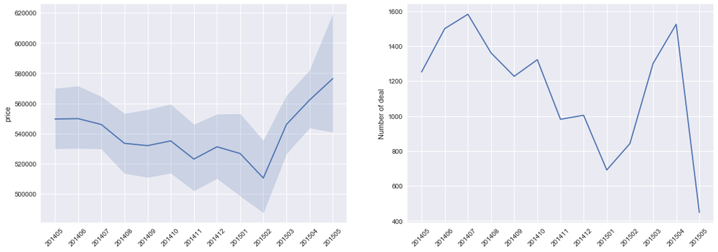

```python
f, ax = plt.subplots(1,2, figsize=(18,6))
sns.lineplot(x='YYYYMM', y='price', data=df_train, ax=ax[0])
ax[0].set_xlabel('')
ax[0].tick_params(axis='x', which='both', rotation=45)

sns.lineplot(x='YYYYMM', y='price', data=df_train[['YYYYMM','price']].groupby('YYYYMM', as_index=False).count(), ax=ax[1])
ax[1].set_xlabel('')
ax[1].set_ylabel('Number of deal')
ax[1].tick_params(axis='x', which='both', rotation=45)
```

### **4 - BEDROOMS**

침실의 수 입니다.  
당연히 침실의 수와 가격의 개수는 비례 할 것으로 생각되었지만,  
어째서인지 9개, 10개가 되면 오히려 평균가격이 떨어져 보이네요.  
또한, 산점도로 뿌려보면 오히려 5와 6을 기준으로 산모양의 그래프를 보여줍니다.

```python
df_train['bedrooms'].dtype
```

```
dtype('int64')
```

```python
df_train['bedrooms'].describe(include='all')
```

```
count    15035.000000
mean         3.369139
std          0.902721
min          0.000000
25%          3.000000
50%          3.000000
75%          4.000000
max         10.000000
Name: bedrooms, dtype: float64
```

```python
df_train[['bedrooms','price']].groupby('bedrooms').mean().astype('int')
```

| bedrooms | price |
| --- | --- |
| 0 | 240500 |
| 1 | 310289 |
| 2 | 399213 |
| 3 | 465741 |
| 4 | 634061 |
| 5 | 802258 |
| 6 | 871403 |
| 7 | 966948 |
| 8 | 1135300 |
| 9 | 792799 |
| 10 | 899000 |

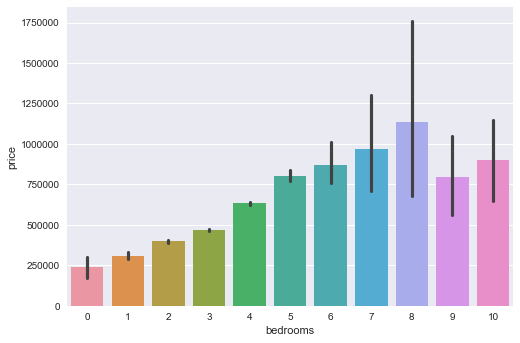

```python
sns.barplot(x='bedrooms', y='price', data=df_train[['price','bedrooms']])
```

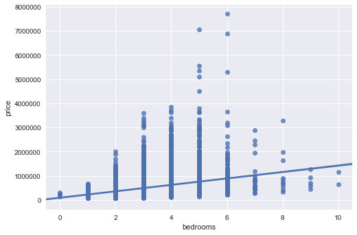

```python
sns.regplot(x='bedrooms', y='price', data=df_train)
```

### **5 - BATHROOMS**

욕실의 수 입니다.  
전반적으로는 욕실의 개수가 증가 할 수록 평균금액역시 증가하는 것으로 보입니다.

```python
df_train['bathrooms'].dtype
```

```
dtype('float64')
```

```python
df_train['bathrooms'].describe(include='all')
```

```
count    15035.000000
mean         2.115065
std          0.767519
min          0.000000
25%          1.750000
50%          2.250000
75%          2.500000
max          8.000000
Name: bathrooms, dtype: float64
```

```python
df_train['bathrooms'].head()
```

```
0    1.00
1    1.00
2    2.00
3    2.25
4    1.50
Name: bathrooms, dtype: float64
```

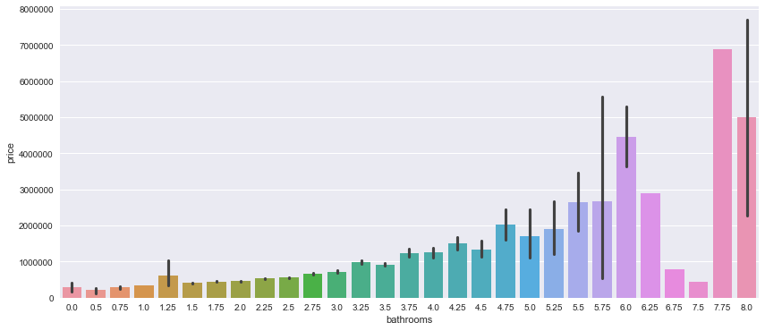

```python
f,ax=plt.subplots(1,1,figsize=(14,6))
sns.barplot(x='bathrooms', y='price', data=df_train)
```

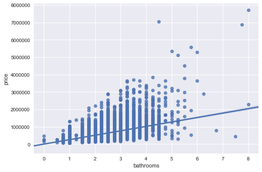

```python
sns.regplot(x='bathrooms', y='price', data=df_train)
```

### **6 - SQFT_LIVING**

주거공간의 면적입니다.  
역시 전반적으로는 면적이 클 수록, price도 따라서 증가하는 것으로 보여집니다.

```python
df_train['sqft_living'].dtype
```

```
dtype('int64')
```

```python
df_train['sqft_living'].describe(include='all')
```

```
count    15035.000000
mean      2083.790223
std        922.134087
min        290.000000
25%       1430.000000
50%       1910.000000
75%       2560.000000
max      13540.000000
Name: sqft_living, dtype: float64
```

```python
df_train['sqft_living'].head()
```

```
0    1180
1     770
2    1680
3    1715
4    1060
Name: sqft_living, dtype: int64
```

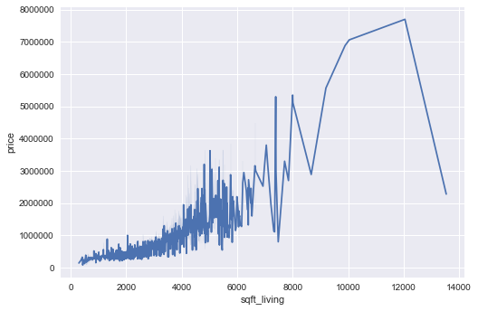

```python
sns.lineplot(x='sqft_living', y='price', data=df_train)
```

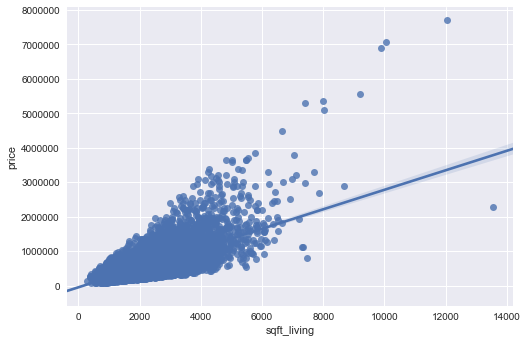

```python
sns.regplot(x='sqft_living', y='price', data=df_train)
```

### **7 - SQFT_LOT**

부지의 면적입니다.  
0에 가까운 굉장히 데이터가 많으며, 집값의 가격에도 의외로 큰 영향을 주지 않는 것 같습니다.

```python
df_train['sqft_lot'].dtype
```

```
dtype('int64')
```

```python
df_train['sqft_lot'].describe(include='all').astype('int')
```

```
count      15035
mean       15296
std        42612
min          520
25%         5027
50%         7620
75%        10695
max      1651359
Name: sqft_lot, dtype: int32
```

```python
df_train['sqft_lot'].head()
```

```
0     5650
1    10000
2     8080
3     6819
4     9711
Name: sqft_lot, dtype: int64
```

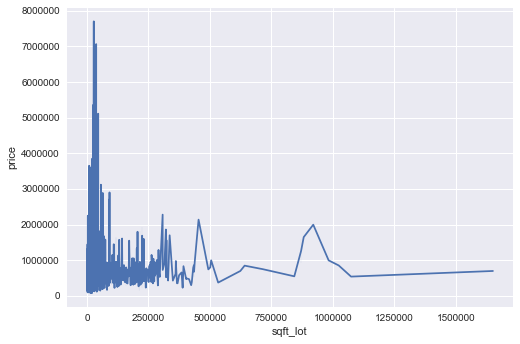

```python
sns.lineplot(x='sqft_lot', y='price', data=df_train)
```

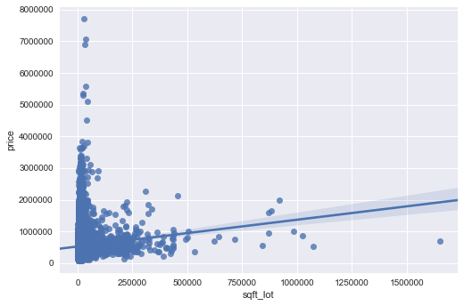

```python
sns.regplot(x='sqft_lot',y='price', data=df_train)
```

### **8 - FLOORS**

집의 층수입니다.  
미국의 단독주택들 뿐인지 최대 3.5층까지 있습니다.  
2.5층까지는 층수가 금액에 영향을 미치는 듯 보이나, 2.5층 부터는 그렇지 못한 모습을 보여줍니다.  
또한 산점도로 비추어보면 고액의 집들은 층수에 크게 구애받지 않는것으로 보이는 듯 합니다.

```python
df_train['floors'].dtype
```

```
dtype('float64')
```

```python
df_train['floors'].describe(include='all')
```

```
count    15035.000000
mean         1.498071
std          0.538522
min          1.000000
25%          1.000000
50%          1.500000
75%          2.000000
max          3.500000
Name: floors, dtype: float64
```

```python
df_train.head()
```

|  | id | date | price | bedrooms | bathrooms | sqft_living | sqft_lot | floors | waterfront | view | condition | grade | sqft_above | sqft_basement | yr_built | yr_renovated | zipcode | lat | long | sqft_living15 | sqft_lot15 | YYYYMM |
| --- | --- | --- | --- | --- | --- | --- | --- | --- | --- | --- | --- | --- | --- | --- | --- | --- | --- | --- | --- | --- | --- | --- |
| 0 | 0 | 20141013T000000 | 221900.0 | 3 | 1.00 | 1180 | 5650 | 1.0 | 0 | 0 | 3 | 7 | 1180 | 0 | 1955 | 0 | 98178 | 47.5112 | -122.257 | 1340 | 5650 | 201410 |
| 1 | 1 | 20150225T000000 | 180000.0 | 2 | 1.00 | 770 | 10000 | 1.0 | 0 | 0 | 3 | 6 | 770 | 0 | 1933 | 0 | 98028 | 47.7379 | -122.233 | 2720 | 8062 | 201502 |
| 2 | 2 | 20150218T000000 | 510000.0 | 3 | 2.00 | 1680 | 8080 | 1.0 | 0 | 0 | 3 | 8 | 1680 | 0 | 1987 | 0 | 98074 | 47.6168 | -122.045 | 1800 | 7503 | 201502 |
| 3 | 3 | 20140627T000000 | 257500.0 | 3 | 2.25 | 1715 | 6819 | 2.0 | 0 | 0 | 3 | 7 | 1715 | 0 | 1995 | 0 | 98003 | 47.3097 | -122.327 | 2238 | 6819 | 201406 |
| 4 | 4 | 20150115T000000 | 291850.0 | 3 | 1.50 | 1060 | 9711 | 1.0 | 0 | 0 | 3 | 7 | 1060 | 0 | 1963 | 0 | 98198 | 47.4095 | -122.315 | 1650 | 9711 | 201501 |

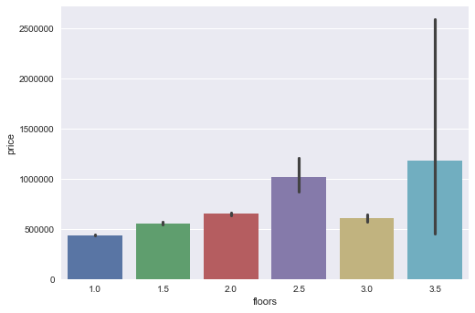

```python
sns.barplot(x='floors', y='price', data=df_train )
```

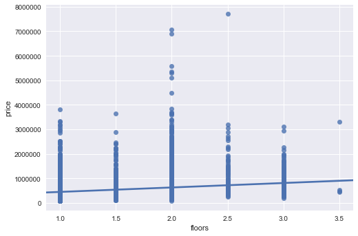

```python
sns.regplot(x='floors', y='price', data=df_train)
```

### **9 - WATERFRONT**

집의 전방에 강이 흐르는지 유무 입니다.  
평균 구매금액으로 봤을 때, 무려 3배가 넘는 가격차이를 보여줍니다.

```python
df_train['waterfront'].dtype
```

```
dtype('int64')
```

```python
df_train['waterfront'].describe(include='all')
```

```
count    15035.000000
mean         0.007117
std          0.084063
min          0.000000
25%          0.000000
50%          0.000000
75%          0.000000
max          1.000000
Name: waterfront, dtype: float64
```

```python
df_train['waterfront'].head()
```

```
0    0
1    0
2    0
3    0
4    0
Name: waterfront, dtype: int64
```

```python
df_train['waterfront'].unique()
```

```
array([0, 1], dtype=int64)
```

```python
df_train[['waterfront','price']].groupby('waterfront').mean().astype('int')
```

| waterfront | price |
| --- | --- |
| 0 | 532324 |
| 1 | 1706784 |

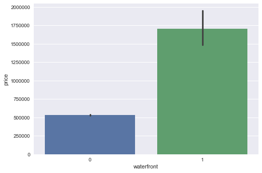

```python
sns.barplot(x='waterfront',y='price', data=df_train)
```

### **10 - VIEW**

0등급부터 4등급까지 총 5개로 이루어져있습니다.  
등급이 올라갈수록 가격 영향력을 미치는 것으로 보입니다.

```python
df_train['view'].dtype
```

```
dtype('int64')
```

```python
df_train['view'].describe(include='all')
```

```
count    15035.000000
mean         0.234253
std          0.763376
min          0.000000
25%          0.000000
50%          0.000000
75%          0.000000
max          4.000000
Name: view, dtype: float64
```

```python
df_train['view'].unique()
```

```
array([0, 3, 4, 2, 1], dtype=int64)
```

```python
df_train[['view','price']].groupby('view').mean().astype('int')
```

| view | price |
| --- | --- |
| 0 | 496285 |
| 1 | 787205 |
| 2 | 805654 |
| 3 | 986627 |
| 4 | 1499978 |

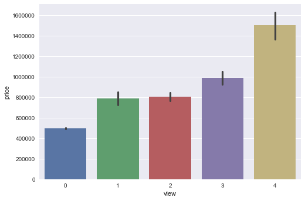

```python
sns.barplot(x='view', y='price', data=df_train)
```

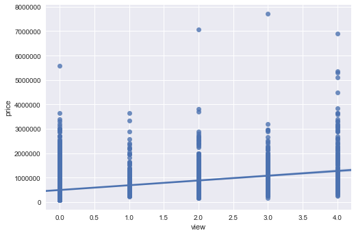

```python
sns.regplot(x='view', y='price', data=df_train)
```

### **11 - CONDITION**

집의 전반적인 상태입니다.  
1부터 5까지 5개의 등급으로 이루어져있습니다.  
저는 등급이 price에 꽤 반영이 된다고 생각했는데 막상 regplot으로 기울기 살펴보면 상관관계가 별로 없다고 보여지네요.

```python
df_train['condition'].dtype
```

```
dtype('int64')
```

```python
df_train['condition'].describe(include='all')
```

```
count    15035.000000
mean         3.406651
std          0.646505
min          1.000000
25%          3.000000
50%          3.000000
75%          4.000000
max          5.000000
Name: condition, dtype: float64
```

```python
df_train['condition'].head()
```

```
0    3
1    3
2    3
3    3
4    3
Name: condition, dtype: int64
```

```python
df_train['condition'].unique()
```

```
array([3, 4, 5, 2, 1], dtype=int64)
```

```python
df_train[['condition','price']].groupby('condition').mean().astype('int')
```

| condition | price |
| --- | --- |
| 1 | 276592 |
| 2 | 325228 |
| 3 | 541062 |
| 4 | 526107 |
| 5 | 612704 |

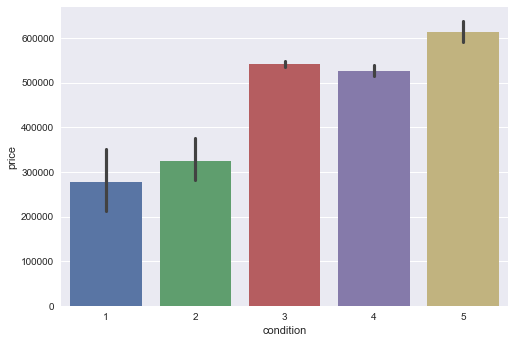

```python
sns.barplot(x='condition', y='price', data=df_train)
```

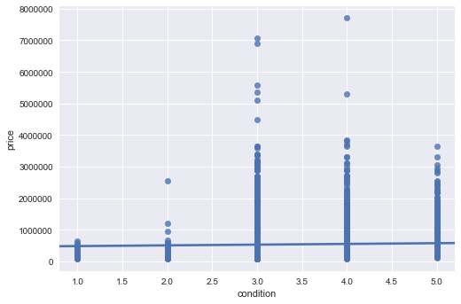

```python
sns.regplot(x='condition', y='price', data=df_train)
```

### **12 - GRADE**

King County grading 시스템 기준으로 매긴 집의 등급 이라는군요.  
1등급 부터 13등급까지 이루어져있습니다. (2등급이 없는건 단순히 이번 데이터에 존재하지 않은건지 싶군요.)  
3~6등급까지는 차이가 없는 듯 보이지만, 6등급 이후로는 굉장히 큰 변별력을 보여줍니다.

```python
df_train['grade'].dtype
```

```
dtype('int64')
```

```python
df_train['grade'].describe(include='all')
```

```
count    15035.000000
mean         7.660725
std          1.179803
min          1.000000
25%          7.000000
50%          7.000000
75%          8.000000
max         13.000000
Name: grade, dtype: float64
```

```python
df_train.head()
```

|  | id | date | price | bedrooms | bathrooms | sqft_living | sqft_lot | floors | waterfront | view | condition | grade | sqft_above | sqft_basement | yr_built | yr_renovated | zipcode | lat | long | sqft_living15 | sqft_lot15 | YYYYMM |
| --- | --- | --- | --- | --- | --- | --- | --- | --- | --- | --- | --- | --- | --- | --- | --- | --- | --- | --- | --- | --- | --- | --- |
| 0 | 0 | 20141013T000000 | 221900.0 | 3 | 1.00 | 1180 | 5650 | 1.0 | 0 | 0 | 3 | 7 | 1180 | 0 | 1955 | 0 | 98178 | 47.5112 | -122.257 | 1340 | 5650 | 201410 |
| 1 | 1 | 20150225T000000 | 180000.0 | 2 | 1.00 | 770 | 10000 | 1.0 | 0 | 0 | 3 | 6 | 770 | 0 | 1933 | 0 | 98028 | 47.7379 | -122.233 | 2720 | 8062 | 201502 |
| 2 | 2 | 20150218T000000 | 510000.0 | 3 | 2.00 | 1680 | 8080 | 1.0 | 0 | 0 | 3 | 8 | 1680 | 0 | 1987 | 0 | 98074 | 47.6168 | -122.045 | 1800 | 7503 | 201502 |
| 3 | 3 | 20140627T000000 | 257500.0 | 3 | 2.25 | 1715 | 6819 | 2.0 | 0 | 0 | 3 | 7 | 1715 | 0 | 1995 | 0 | 98003 | 47.3097 | -122.327 | 2238 | 6819 | 201406 |
| 4 | 4 | 20150115T000000 | 291850.0 | 3 | 1.50 | 1060 | 9711 | 1.0 | 0 | 0 | 3 | 7 | 1060 | 0 | 1963 | 0 | 98198 | 47.4095 | -122.315 | 1650 | 9711 | 201501 |

```python
a = df_train['grade'].unique()
sorted(a)
```

```
[1, 3, 4, 5, 6, 7, 8, 9, 10, 11, 12, 13]
```

```python
df_train[['grade','price']].groupby('grade').mean().astype('int')
```

| grade | price |
| --- | --- |
| 1 | 142000 |
| 3 | 271000 |
| 4 | 209741 |
| 5 | 251069 |
| 6 | 300155 |
| 7 | 401528 |
| 8 | 542315 |
| 9 | 773478 |
| 10 | 1062482 |
| 11 | 1522458 |
| 12 | 2220540 |
| 13 | 4132333 |

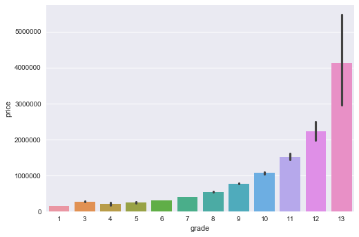

```python
sns.barplot(x='grade', y='price', data=df_train)
```

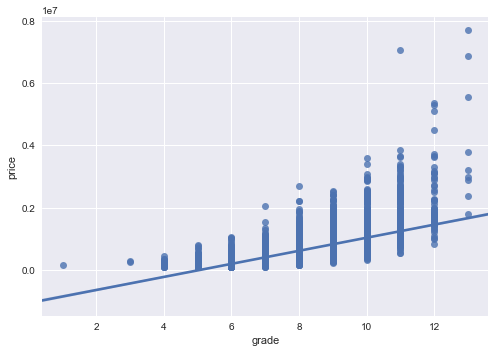

```python
sns.regplot(x='grade', y='price', data=df_train)
```

### **13 - SQFT_ABOVE**

지하실을 제외한 평방피트, 지상층 면적입니다.  
면적이 클 수록, 가격이 증가하는 추세가 보입니다.

```python
df_train['sqft_above'].dtype
```

```
dtype('int64')
```

```python
df_train['sqft_above'].describe(include='all')
```

```
count    15035.000000
mean      1794.158164
std        831.738609
min        290.000000
25%       1190.000000
50%       1570.000000
75%       2230.000000
max       9410.000000
Name: sqft_above, dtype: float64
```

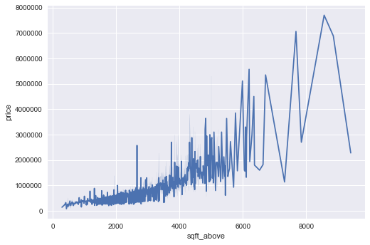

```python
sns.lineplot(x='sqft_above', y='price', data=df_train)
```

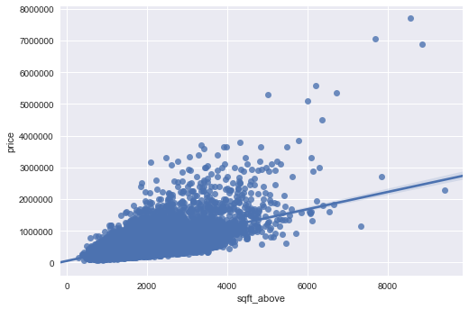

```python
sns.regplot(x='sqft_above', y='price', data=df_train)
```

### **14 - SQFT_BASEMENT**

지하실의 평방피트, 면적입니다.  
지하실이 존재하지 않는 (면적이 0인) 데이터가 꽤 많이 증가합니다.  
하지만 일단은 면적이 증가 할 수록 가격이 증가하는 추세가 보입니다.

```python
df_train['sqft_basement'].dtype
```

```
dtype('int64')
```

```python
df_train['sqft_basement'].describe(include='all')
```

```
count    15035.000000
mean       289.632059
std        440.663284
min          0.000000
25%          0.000000
50%          0.000000
75%        550.000000
max       4130.000000
Name: sqft_basement, dtype: float64
```

```python
df_train['sqft_basement'].head()
```

```
0    0
1    0
2    0
3    0
4    0
Name: sqft_basement, dtype: int64
```

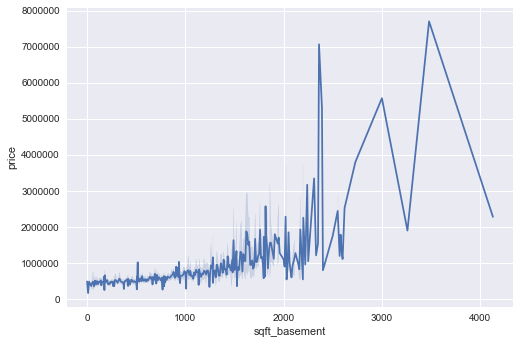

```python
sns.lineplot(x='sqft_basement', y='price', data=df_train)
```

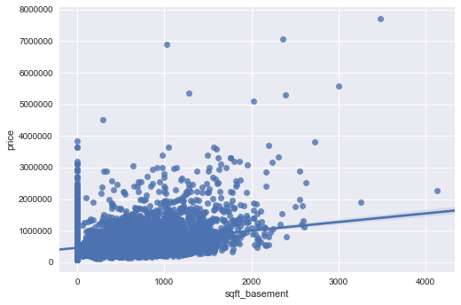

```python
sns.regplot(x='sqft_basement', y='price', data=df_train)
```

```python
df_train['sqft_basement'][df_train['sqft_basement']==0].count()
```

```
9143
```

### **15 - YR_BUILT**

집이 지어진 년도입니다.  
1900년도부터 2015년도 까지 꽤 다양하게 존재하고 있습니다.  
집이 지어진 년도와, 집값의 관계는 의외로 별 추세를 가지지 않는것으로 보입니다.

```python
df_train['yr_built'].dtype
```

```
dtype('int64')
```

```python
df_train['yr_built'].describe(include='all')
```

```
count    15035.000000
mean      1971.100432
std         29.407612
min       1900.000000
25%       1951.000000
50%       1975.000000
75%       1997.000000
max       2015.000000
Name: yr_built, dtype: float64
```

```python
df_train['yr_built'].head()
```

```
0    1955
1    1933
2    1987
3    1995
4    1963
Name: yr_built, dtype: int64
```

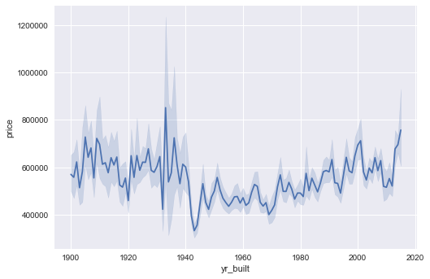

```python
sns.lineplot(x='yr_built', y='price', data=df_train)
```

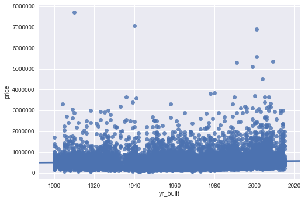

```python
sns.regplot(x='yr_built', y='price', data=df_train)
```

### **16 - YR_RENOVATED**

집을 재 건축한 년도입니다.  
1940년도 부터 2015년도 까지 다양하게 존재합니다.  
재건축을 안한 (data가 0인) 값이 굉장히 많습니다.  
재건축년도와 가격에는 미세하게 추세를 띄고 있는것으로 보입니다.

```python
df_train['yr_renovated'].dtype
```

```
dtype('int64')
```

```python
df_train['yr_renovated'].describe(include='all')
```

```
count    15035.000000
mean        83.798936
std        400.398498
min          0.000000
25%          0.000000
50%          0.000000
75%          0.000000
max       2015.000000
Name: yr_renovated, dtype: float64
```

```python
df_train['yr_renovated'].head()
```

```
0    0
1    0
2    0
3    0
4    0
Name: yr_renovated, dtype: int64
```

```python
print('year starts from : {}'.format(sorted(df_train['yr_renovated'].unique())[1]))
print('year ends to : {}'.format(df_train['yr_renovated'].max()))
```

```
year starts from : 1940
year ends to : 2015
```

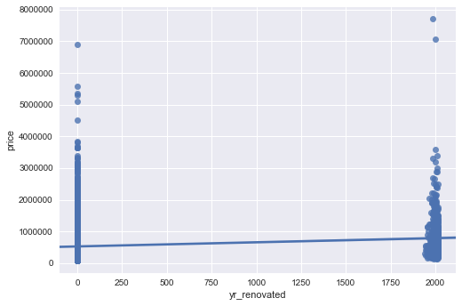

```python
sns.regplot(x='yr_renovated', y='price', data=df_train)
```

```python
df_train['yr_renovated'][df_train['yr_renovated']==0].count()
```

```
14404
```

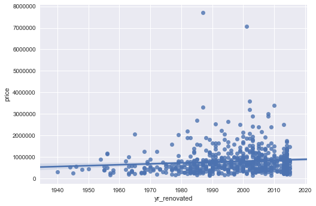

```python
sns.regplot(x='yr_renovated', y='price', data=df_train[df_train['yr_renovated']!=0])
```

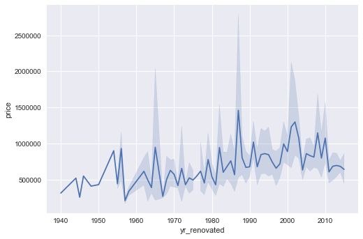

```python
sns.lineplot(x='yr_renovated', y='price', data=df_train[df_train['yr_renovated']!=0])
```

### **17 - ZIPCODE**

### **18 - LAT**

### **19 - LONG**

우편번호, 위도, 경도는 위치정보를 대표할 수 있습니다.  
해당 feature들에 대해서는 나중에 다시 다뤄보겠습니다.

### **20 - SQFT_LIVING15**

2015년 기준 주거 공간의 평방 피트(면적, 집을 재건축했다면, 변화가 있을 수 있음)  
sqft_living과 sqft_living15의 데이터를 둘 다 사용할 필요는 없는 것 같습니다.  
또한 sqft가 기존면적에 비해서 2015년도 기준으로 최대면적들이 많이 줄어든 것이 확인됩니다.  
(7000이상의 면적을 가진 집들이 다수 존재했었으나 2015년도 기준에는 6210sqft가 최대.)

```python
df_train['sqft_living15'].dtype
```

```
dtype('int64')
```

```python
df_train['sqft_living15'].describe(include='all')
```

```
count    15035.000000
mean      1992.754772
std        691.456442
min        399.000000
25%       1490.000000
50%       1850.000000
75%       2360.000000
max       6210.000000
Name: sqft_living15, dtype: float64
```

```python
df_train['sqft_living15'].head()
```

```
0    1340
1    2720
2    1800
3    2238
4    1650
Name: sqft_living15, dtype: int64
```

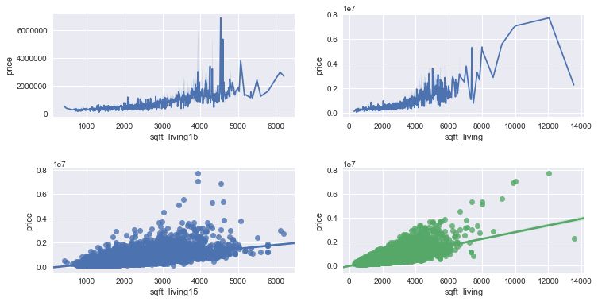

```python
f, ax = plt.subplots(2,2, figsize=(12,6))

sns.lineplot(x='sqft_living15', y='price', data=df_train, ax=ax[0,0])
sns.lineplot(x='sqft_living', y='price', data=df_train, ax=ax[0,1])

sns.regplot(x='sqft_living15', y='price', data=df_train, ax=ax[1,0])
sns.regplot(x='sqft_living', y='price', data=df_train, ax=ax[1,1])

plt.subplots_adjust(hspace=0.5)
```

### **21 - SQFT_LOT15**

2015년 기준 부지의 평방 피트(면적, 집을 재건축했다면, 변화가 있을 수 있음)  
sqft_living과 마찬가지로, 부지의 면적 역시 sqft_lot과 sqft_lot15 둘 다 있어야 할 필요는 없는 것 같습니다.

```python
df_train['sqft_lot15'].dtype
```

```
dtype('int64')
```

```python
df_train['sqft_lot15'].describe(include='all')
```

```
count     15035.000000
mean      12823.884935
std       27736.259787
min         651.000000
25%        5100.000000
50%        7610.000000
75%       10076.000000
max      871200.000000
Name: sqft_lot15, dtype: float64
```

```python
df_train.head()
```

|  | id | date | price | bedrooms | bathrooms | sqft_living | sqft_lot | floors | waterfront | view | condition | grade | sqft_above | sqft_basement | yr_built | yr_renovated | zipcode | lat | long | sqft_living15 | sqft_lot15 | YYYYMM |
| --- | --- | --- | --- | --- | --- | --- | --- | --- | --- | --- | --- | --- | --- | --- | --- | --- | --- | --- | --- | --- | --- | --- |
| 0 | 0 | 20141013T000000 | 221900.0 | 3 | 1.00 | 1180 | 5650 | 1.0 | 0 | 0 | 3 | 7 | 1180 | 0 | 1955 | 0 | 98178 | 47.5112 | -122.257 | 1340 | 5650 | 201410 |
| 1 | 1 | 20150225T000000 | 180000.0 | 2 | 1.00 | 770 | 10000 | 1.0 | 0 | 0 | 3 | 6 | 770 | 0 | 1933 | 0 | 98028 | 47.7379 | -122.233 | 2720 | 8062 | 201502 |
| 2 | 2 | 20150218T000000 | 510000.0 | 3 | 2.00 | 1680 | 8080 | 1.0 | 0 | 0 | 3 | 8 | 1680 | 0 | 1987 | 0 | 98074 | 47.6168 | -122.045 | 1800 | 7503 | 201502 |
| 3 | 3 | 20140627T000000 | 257500.0 | 3 | 2.25 | 1715 | 6819 | 2.0 | 0 | 0 | 3 | 7 | 1715 | 0 | 1995 | 0 | 98003 | 47.3097 | -122.327 | 2238 | 6819 | 201406 |
| 4 | 4 | 20150115T000000 | 291850.0 | 3 | 1.50 | 1060 | 9711 | 1.0 | 0 | 0 | 3 | 7 | 1060 | 0 | 1963 | 0 | 98198 | 47.4095 | -122.315 | 1650 | 9711 | 201501 |

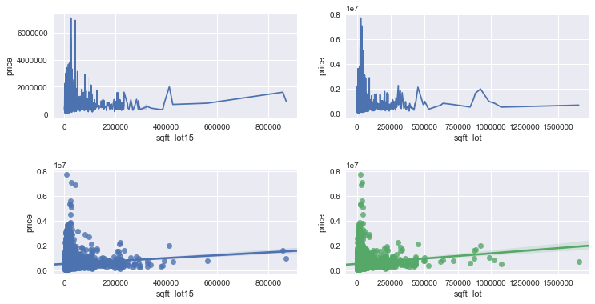

```python
f, ax = plt.subplots(2,2, figsize=(12,6))

sns.lineplot(x='sqft_lot15', y='price', data=df_train, ax=ax[0,0])
sns.lineplot(x='sqft_lot', y='price', data=df_train, ax=ax[0,1])

sns.regplot(x='sqft_lot15', y='price', data=df_train, ax=ax[1,0])
sns.regplot(x='sqft_lot', y='price', data=df_train, ax=ax[1,1])

plt.subplots_adjust(hspace=0.5)
```

### **22 - EDA 마무리**

우선  
price, id 는 불필요한 feature이므로 제외  
lat, long, zipcode 에서는 주소정보를 추출해서 재가공하기로 하고  
sqft_living, sqft_living15, sqft_lot sqft_lot15 역시 중복값으로 생각하고 주거지면적, 부지면적 하나씩만 추출하여 재가공

그리고 남은 feature들의 상관정도는  
grade, sqft_above, bathrooms, view, bedrooms, sqft_basement, waterfront, floors, yr_renovated, yr_built, condition 순서입니다.

```python
df_train.head()
```

|  | id | date | price | bedrooms | bathrooms | sqft_living | sqft_lot | floors | waterfront | view | condition | grade | sqft_above | sqft_basement | yr_built | yr_renovated | zipcode | lat | long | sqft_living15 | sqft_lot15 | YYYYMM |
| --- | --- | --- | --- | --- | --- | --- | --- | --- | --- | --- | --- | --- | --- | --- | --- | --- | --- | --- | --- | --- | --- | --- |
| 0 | 0 | 20141013T000000 | 221900.0 | 3 | 1.00 | 1180 | 5650 | 1.0 | 0 | 0 | 3 | 7 | 1180 | 0 | 1955 | 0 | 98178 | 47.5112 | -122.257 | 1340 | 5650 | 201410 |
| 1 | 1 | 20150225T000000 | 180000.0 | 2 | 1.00 | 770 | 10000 | 1.0 | 0 | 0 | 3 | 6 | 770 | 0 | 1933 | 0 | 98028 | 47.7379 | -122.233 | 2720 | 8062 | 201502 |
| 2 | 2 | 20150218T000000 | 510000.0 | 3 | 2.00 | 1680 | 8080 | 1.0 | 0 | 0 | 3 | 8 | 1680 | 0 | 1987 | 0 | 98074 | 47.6168 | -122.045 | 1800 | 7503 | 201502 |
| 3 | 3 | 20140627T000000 | 257500.0 | 3 | 2.25 | 1715 | 6819 | 2.0 | 0 | 0 | 3 | 7 | 1715 | 0 | 1995 | 0 | 98003 | 47.3097 | -122.327 | 2238 | 6819 | 201406 |
| 4 | 4 | 20150115T000000 | 291850.0 | 3 | 1.50 | 1060 | 9711 | 1.0 | 0 | 0 | 3 | 7 | 1060 | 0 | 1963 | 0 | 98198 | 47.4095 | -122.315 | 1650 | 9711 | 201501 |

```python
def corrsort(targetindexname) :
    targetindex = df_train.columns.get_loc(targetindexname)
    corrtarget = df_train.corr().iloc[:,targetindex-1:targetindex]
    corrtargetsort = 'corrtarget.reindex(corrtarget.'+targetindexname+'.abs().sort_values(ascending=False).index)'
    print(eval(corrtargetsort))
    print('--'*20)
    #for i in eval(corrtargetsort).index.tolist() :
    #    print('\''+i+'\',')
```

```python
corrsort('price')
```

```
                  price
price          1.000000
sqft_living    0.702899
grade          0.667211
sqft_above     0.608577
sqft_living15  0.586419
bathrooms      0.525479
view           0.400806
bedrooms       0.323672
sqft_basement  0.322218
lat            0.301604
waterfront     0.265738
floors         0.262588
yr_renovated   0.140808
sqft_lot       0.096793
sqft_lot15     0.086384
zipcode       -0.051498
yr_built       0.047290
condition      0.039740
long           0.023547
id             0.020899
----------------------------------------
```

## **Chapter 4 - Data Cleaning**

```python
#### 테이블 임시저장
#temp_df_train = copy.deepcopy(df_train)
#temp_df_test = copy.deepcopy(df_test)
######################################################
######################################################
######################################################
```

```python
#df_train = copy.deepcopy(temp_df_train)
#df_test = copy.deepcopy(temp_df_test)
```

```python
df_train.head()
```

|  | id | date | price | bedrooms | bathrooms | sqft_living | sqft_lot | floors | waterfront | view | condition | grade | sqft_above | sqft_basement | yr_built | yr_renovated | zipcode | lat | long | sqft_living15 | sqft_lot15 | YYYYMM |
| --- | --- | --- | --- | --- | --- | --- | --- | --- | --- | --- | --- | --- | --- | --- | --- | --- | --- | --- | --- | --- | --- | --- |
| 0 | 0 | 20141013T000000 | 221900.0 | 3 | 1.00 | 1180 | 5650 | 1.0 | 0 | 0 | 3 | 7 | 1180 | 0 | 1955 | 0 | 98178 | 47.5112 | -122.257 | 1340 | 5650 | 201410 |
| 1 | 1 | 20150225T000000 | 180000.0 | 2 | 1.00 | 770 | 10000 | 1.0 | 0 | 0 | 3 | 6 | 770 | 0 | 1933 | 0 | 98028 | 47.7379 | -122.233 | 2720 | 8062 | 201502 |
| 2 | 2 | 20150218T000000 | 510000.0 | 3 | 2.00 | 1680 | 8080 | 1.0 | 0 | 0 | 3 | 8 | 1680 | 0 | 1987 | 0 | 98074 | 47.6168 | -122.045 | 1800 | 7503 | 201502 |
| 3 | 3 | 20140627T000000 | 257500.0 | 3 | 2.25 | 1715 | 6819 | 2.0 | 0 | 0 | 3 | 7 | 1715 | 0 | 1995 | 0 | 98003 | 47.3097 | -122.327 | 2238 | 6819 | 201406 |
| 4 | 4 | 20150115T000000 | 291850.0 | 3 | 1.50 | 1060 | 9711 | 1.0 | 0 | 0 | 3 | 7 | 1060 | 0 | 1963 | 0 | 98198 | 47.4095 | -122.315 | 1650 | 9711 | 201501 |

### **Chapter 4 - 1 - Correcting**

비정상 데이터를 단정하기 어려워 별도의 작업 없이 지나가도록 하겠습니다.

### **Chapter 4 - 2 - Completing**

데이터의 결측치들을 채워넣습니다.  
이번 competition에서는 결측치가 없으므로, 지나가겠습니다.

### **Chapter 4 - 3 - Creating**

기존 변수로부터, 새로운 변수를 도출합니다.  
zip, lot, long 으로부터 주소정보를 도출해보겠습니다.  
zipcode별 sqft당 평균 땅값, 땅값*해당집값의 sqft, zipcode별 평균 집값, 지상 지하 합면적,  
zipcode로부터 city를 추출하고, city별 평균집값을 추출했습니다.

```python
## zipcode별 sqft당 평균땅값
df_zipsum = df_train[['zipcode','sqft_lot']].groupby('zipcode', as_index = False).sum()
df_zipcount = df_train[['zipcode','price']].groupby('zipcode', as_index=False).sum()
df_zip_avg = pd.merge(df_zipsum, df_zipcount, on='zipcode')
df_zip_avg['zip_avg_price'] = df_zip_avg['price'] / df_zip_avg['sqft_lot']

df_train = pd.merge(df_train, df_zip_avg[['zipcode','zip_avg_price']], on ='zipcode', how='left')
df_test =  pd.merge(df_test,  df_zip_avg[['zipcode','zip_avg_price']], on ='zipcode', how='left')
```

```python
# zipcode별 sqft당 평균땅값 * 부지
df_train['zipvalue'] =  df_train['zip_avg_price']*df_train['sqft_lot']
df_test['zipvalue'] =  df_test['zip_avg_price']*df_test['sqft_lot']
```

```python
## zipcode별 평균 집값
df_zip_mean = df_train[['zipcode','price']].groupby('zipcode', as_index=False).mean()
df_zip_mean.rename(columns={'price':'zip_avg_house_price'}, inplace=True)
df_train = pd.merge(df_train, df_zip_mean[['zipcode','zip_avg_house_price']], on ='zipcode', how='left')
df_test = pd.merge(df_test, df_zip_mean[['zipcode','zip_avg_house_price']], on ='zipcode', how='left')
```

```python
#지상지하 합면적
df_train['totallot'] = df_train['sqft_above'] + df_train['sqft_basement']
df_test['totallot'] = df_test['sqft_above'] + df_test['sqft_basement']
```

```python
# city from zipcode
from uszipcode import SearchEngine
search = SearchEngine(simple_zipcode=True)

states =[]
for i in df_train['zipcode'] :
    states.append(search.by_zipcode(i).values()[3])
df_train['states'] = states

states =[]
for i in df_test['zipcode'] :
    states.append(search.by_zipcode(i).values()[3])
df_test['states'] = states
```

```python
# city별 평균집값
df_states_mean = df_train[['states','price']].groupby('states', as_index=False).mean()
df_states_mean.rename(columns={'price':'states_avg_house_price'}, inplace=True)
df_train = pd.merge(df_train, df_states_mean[['states','states_avg_house_price']], on ='states', how='left')
df_test = pd.merge(df_test, df_states_mean[['states','states_avg_house_price']], on ='states', how='left')
```

### **Chapter 4 - 4 - Convert**

```python
df_train['YYYYMM'] = df_train['YYYYMM'].astype('int')
df_test['YYYYMM'] = df_test['YYYYMM'].astype('int')
```

```python
## one-hot encoding
df_train = pd.get_dummies(df_train, columns=['states'], prefix='Initial')
df_test = pd.get_dummies(df_test, columns=['states'], prefix='Initial')
```

### **Chapter 4 - 5 - Drop Column & Check data sets**

```python
drop_column = ['id','date','zipcode', 'sqft_lot', 'sqft_living', 'sqft_basement'] #

df_train.drop(drop_column, axis=1, inplace = True)
df_test.drop(drop_column, axis=1, inplace = True)
```

## **Chapter 5 - Model Data**

이제 지금까지 지금까지 살펴보고, 가공한 데이터로 머신러닝 모델을 만들어보겠습니다.

### **Chapter 5 - 1 - Model Generation and Prediction and Evaluation**

```python
df_train.head()
```

|  | price | bedrooms | bathrooms | floors | waterfront | view | condition | grade | sqft_above | yr_built | yr_renovated | lat | long | sqft_living15 | sqft_lot15 | YYYYMM | zip_avg_price | zipvalue | zip_avg_house_price | totallot | states_avg_house_price | Initial_Auburn, WA | Initial_Bellevue, WA | Initial_Black Diamond, WA | Initial_Bothell, WA | Initial_Carnation, WA | Initial_Duvall, WA | Initial_Enumclaw, WA | Initial_Fall City, WA | … |
| --- | --- | --- | --- | --- | --- | --- | --- | --- | --- | --- | --- | --- | --- | --- | --- | --- | --- | --- | --- | --- | --- | --- | --- | --- | --- | --- | --- | --- | --- | --- |
| 0 | 221900.0 | 3 | 1.00 | 1.0 | 0 | 0 | 3 | 7 | 1180 | 1955 | 0 | 47.5112 | -122.257 | 1340 | 5650 | 201410 | 37.105667 | 209647.021175 | 308083.718750 | 1180 | 534901.148828 | 0 | 0 | 0 | 0 | 0 | 0 | 0 | 0 | … |
| 1 | 180000.0 | 2 | 1.00 | 1.0 | 0 | 0 | 3 | 6 | 770 | 1933 | 0 | 47.7379 | -122.233 | 2720 | 8062 | 201502 | 40.747809 | 407478.089943 | 460595.393035 | 770 | 460595.393035 | 0 | 0 | 0 | 0 | 0 | 0 | 0 | 0 | … |
| 2 | 510000.0 | 3 | 2.00 | 1.0 | 0 | 0 | 3 | 8 | 1680 | 1987 | 0 | 47.6168 | -122.045 | 1800 | 7503 | 201502 | 48.540018 | 392203.343859 | 697933.386441 | 1680 | 734455.318264 | 0 | 0 | 0 | 0 | 0 | 0 | 0 | 0 | … |
| 3 | 257500.0 | 3 | 2.25 | 2.0 | 0 | 0 | 3 | 7 | 1715 | 1995 | 0 | 47.3097 | -122.327 | 2238 | 6819 | 201406 | 26.938842 | 183695.962435 | 288215.610811 | 1715 | 284156.385768 | 0 | 0 | 0 | 0 | 0 | 0 | 0 | 0 | … |
| 4 | 291850.0 | 3 | 1.50 | 1.0 | 0 | 0 | 3 | 7 | 1060 | 1963 | 0 | 47.4095 | -122.315 | 1650 | 9711 | 201501 | 28.545547 | 277205.811152 | 304198.797980 | 1060 | 534901.148828 | 0 | 0 | 0 | 0 | 0 | 0 | 0 | 0 | … |

```python
X_train_data = df_train.drop('price', axis=1).values
X_train_label = df_train['price'].values
X_test_data = df_test.values
```

```python
alg = XGBRegressor(
                     base_score=0.5,
                     booster='gbtree',
                     colsample_bytree=1,
                     importance_type='gain',
                     max_depth=3,
                     min_child_weight=1,
                     n_estimators=10000,
                     n_jobs=1,
                     scale_pos_weight=1,
                     silent=True,
                     gamma=0,
                     random_state=0,
                     reg_alpha=0,
                     reg_lambda=1,
                     subsample=1,
                     learning_rate=0.1
                  )


test_acc = []
xgb_prediction = 0
splits_cnt = 5
kf = KFold(n_splits=splits_cnt ,random_state=0 ,shuffle=True)
for fold_no,(train_index, test_index) in enumerate(kf.split(df_train)):

    train_data, test_data = X_train_data[train_index],  X_train_data[test_index]
    train_label, test_label = X_train_label[train_index], X_train_label[test_index]

    print('-'*50)
    print('fold_no : '+str(fold_no))
    print('-'*50)
    alg.fit(
              train_data, train_label
            , eval_set = [(train_data,train_label),(test_data, test_label)]
            , eval_metric = 'rmse'
            , verbose=1000
            , early_stopping_rounds=500
           )
    print('\n'*2)


    predictions = alg.predict(X_test_data)
    xgb_prediction += predictions

xgb_final = xgb_prediction / splits_cnt
```

[output not shown]

```
Text(0,0.5,'Feature')
```

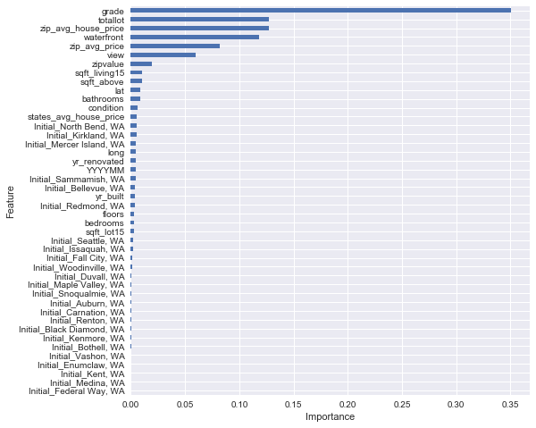

```python
feature_importance = alg.feature_importances_
Series_feat_imp = Series(feature_importance, index=df_test.columns)

plt.figure(figsize = (8,8))
Series_feat_imp.sort_values(ascending=True).plot.barh()
plt.xlabel('Importance')
plt.ylabel('Feature')
```

## **Chapter 6 - Submission**

```python
submission = pd.read_csv('C:/Users/hongo/OneDrive/BIGDATA/kaggle/HousePricePrediction/sample_submission.csv')
```

```python
submission['price'] = xgb_final
```

```python
submission.head()
```

|  | id | price |
| --- | --- | --- |
| 0 | 15035 | 5.184402e+05 |
| 1 | 15036 | 4.921195e+05 |
| 2 | 15037 | 1.470811e+06 |
| 3 | 15038 | 3.378077e+05 |
| 4 | 15039 | 3.234462e+05 |

```python
from IPython.display import Image
from IPython.core.display import HTML
```

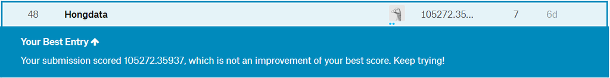

```python
PATH = "C:/Users/hongo/OneDrive/BIGDATA/kaggle/HousePricePrediction/"
Image(filename = PATH + "result.png")
```

Submission 결과입니다.  
rmse와 비슷하게 105000정도의 오차율을 보인 것을 알 수 있습니다.

- 본 결과는 kaggle의 Public leaderboard score로, 총 mission 데이터의 50%만 집계하여 스코어링 합니다.